# Risk Factor Analysis

## Outcome Variable

**Outcome Variable:** whz

## Predictor Variables

**Intervention Variable:** exclfeed36

**Adjustment Set:**

unadjusted

## Stratifying Variables

The analysis was stratified on these variable(s):

- agecat
- studyid
- country

## Data Summary

| agecat | studyid | country | exclfeed36 | n_cell | n |
| --- | --- | --- | --- | --- | --- |
| Birth | ki0047075b-MAL-ED | BANGLADESH | 1 | 58 | 230 |
| Birth | ki0047075b-MAL-ED | BANGLADESH | 0 | 172 | 230 |
| Birth | ki0047075b-MAL-ED | BRAZIL | 1 | 12 | 177 |
| Birth | ki0047075b-MAL-ED | BRAZIL | 0 | 165 | 177 |
| Birth | ki0047075b-MAL-ED | INDIA | 1 | 5 | 195 |
| Birth | ki0047075b-MAL-ED | INDIA | 0 | 190 | 195 |
| Birth | ki0047075b-MAL-ED | NEPAL | 1 | 11 | 167 |
| Birth | ki0047075b-MAL-ED | NEPAL | 0 | 156 | 167 |
| Birth | ki0047075b-MAL-ED | PERU | 1 | 15 | 266 |
| Birth | ki0047075b-MAL-ED | PERU | 0 | 251 | 266 |
| Birth | ki0047075b-MAL-ED | SOUTH AFRICA | 1 | 0 | 234 |
| Birth | ki0047075b-MAL-ED | SOUTH AFRICA | 0 | 234 | 234 |
| Birth | ki0047075b-MAL-ED | TANZANIA, UNITED REPUBLIC OF | 1 | 1 | 116 |
| Birth | ki0047075b-MAL-ED | TANZANIA, UNITED REPUBLIC OF | 0 | 115 | 116 |
| Birth | ki1000108-CMC-V-BCS-2002 | INDIA | 1 | 3 | 3 |
| Birth | ki1000108-CMC-V-BCS-2002 | INDIA | 0 | 0 | 3 |
| Birth | ki1000108-IRC | INDIA | 1 | 0 | 3 |
| Birth | ki1000108-IRC | INDIA | 0 | 3 | 3 |
| Birth | ki1000109-EE | PAKISTAN | 1 | 0 | 1 |
| Birth | ki1000109-EE | PAKISTAN | 0 | 1 | 1 |
| Birth | ki1101329-Keneba | GAMBIA | 1 | 345 | 1202 |
| Birth | ki1101329-Keneba | GAMBIA | 0 | 857 | 1202 |
| Birth | kiGH5241-JiVitA-3 | BANGLADESH | 1 | 9175 | 11319 |
| Birth | kiGH5241-JiVitA-3 | BANGLADESH | 0 | 2144 | 11319 |
| Birth | kiGH5241-JiVitA-4 | BANGLADESH | 1 | 491 | 602 |
| Birth | kiGH5241-JiVitA-4 | BANGLADESH | 0 | 111 | 602 |
| 6 months | ki0047075b-MAL-ED | BANGLADESH | 1 | 63 | 240 |
| 6 months | ki0047075b-MAL-ED | BANGLADESH | 0 | 177 | 240 |
| 6 months | ki0047075b-MAL-ED | BRAZIL | 1 | 17 | 209 |
| 6 months | ki0047075b-MAL-ED | BRAZIL | 0 | 192 | 209 |

[output cut: 60 more lines]

The following strata were considered:

- agecat: 24 months, studyid: ki0047075b-MAL-ED, country: BANGLADESH
- agecat: 24 months, studyid: ki0047075b-MAL-ED, country: BRAZIL
- agecat: 24 months, studyid: ki0047075b-MAL-ED, country: INDIA
- agecat: 24 months, studyid: ki0047075b-MAL-ED, country: NEPAL
- agecat: 24 months, studyid: ki0047075b-MAL-ED, country: PERU
- agecat: 24 months, studyid: ki0047075b-MAL-ED, country: SOUTH AFRICA
- agecat: 24 months, studyid: ki0047075b-MAL-ED, country: TANZANIA, UNITED REPUBLIC OF
- agecat: 24 months, studyid: ki1000108-CMC-V-BCS-2002, country: INDIA
- agecat: 24 months, studyid: ki1000108-IRC, country: INDIA
- agecat: 24 months, studyid: ki1017093b-PROVIDE, country: BANGLADESH
- agecat: 24 months, studyid: ki1101329-Keneba, country: GAMBIA
- agecat: 24 months, studyid: ki1113344-GMS-Nepal, country: NEPAL
- agecat: 24 months, studyid: ki1148112-LCNI-5, country: MALAWI
- agecat: 24 months, studyid: kiGH5241-JiVitA-3, country: BANGLADESH
- agecat: 24 months, studyid: kiGH5241-JiVitA-4, country: BANGLADESH
- agecat: 6 months, studyid: ki0047075b-MAL-ED, country: BANGLADESH
- agecat: 6 months, studyid: ki0047075b-MAL-ED, country: BRAZIL
- agecat: 6 months, studyid: ki0047075b-MAL-ED, country: INDIA
- agecat: 6 months, studyid: ki0047075b-MAL-ED, country: NEPAL
- agecat: 6 months, studyid: ki0047075b-MAL-ED, country: PERU
- agecat: 6 months, studyid: ki0047075b-MAL-ED, country: SOUTH AFRICA
- agecat: 6 months, studyid: ki0047075b-MAL-ED, country: TANZANIA, UNITED REPUBLIC OF
- agecat: 6 months, studyid: ki1000108-CMC-V-BCS-2002, country: INDIA
- agecat: 6 months, studyid: ki1000108-IRC, country: INDIA
- agecat: 6 months, studyid: ki1000109-EE, country: PAKISTAN
- agecat: 6 months, studyid: ki1000304b-SAS-FoodSuppl, country: INDIA
- agecat: 6 months, studyid: ki1017093b-PROVIDE, country: BANGLADESH
- agecat: 6 months, studyid: ki1101329-Keneba, country: GAMBIA
- agecat: 6 months, studyid: ki1113344-GMS-Nepal, country: NEPAL
- agecat: 6 months, studyid: ki1148112-LCNI-5, country: MALAWI
- agecat: 6 months, studyid: kiGH5241-JiVitA-3, country: BANGLADESH
- agecat: 6 months, studyid: kiGH5241-JiVitA-4, country: BANGLADESH
- agecat: Birth, studyid: ki0047075b-MAL-ED, country: BANGLADESH
- agecat: Birth, studyid: ki0047075b-MAL-ED, country: BRAZIL
- agecat: Birth, studyid: ki0047075b-MAL-ED, country: INDIA
- agecat: Birth, studyid: ki0047075b-MAL-ED, country: NEPAL
- agecat: Birth, studyid: ki0047075b-MAL-ED, country: PERU
- agecat: Birth, studyid: ki0047075b-MAL-ED, country: SOUTH AFRICA
- agecat: Birth, studyid: ki0047075b-MAL-ED, country: TANZANIA, UNITED REPUBLIC OF
- agecat: Birth, studyid: ki1000108-CMC-V-BCS-2002, country: INDIA
- agecat: Birth, studyid: ki1000108-IRC, country: INDIA
- agecat: Birth, studyid: ki1000109-EE, country: PAKISTAN
- agecat: Birth, studyid: ki1101329-Keneba, country: GAMBIA
- agecat: Birth, studyid: kiGH5241-JiVitA-3, country: BANGLADESH
- agecat: Birth, studyid: kiGH5241-JiVitA-4, country: BANGLADESH

### Dropped Strata

Some strata were dropped due to rare outcomes:

- agecat: Birth, studyid: ki0047075b-MAL-ED, country: SOUTH AFRICA
- agecat: Birth, studyid: ki0047075b-MAL-ED, country: TANZANIA, UNITED REPUBLIC OF
- agecat: Birth, studyid: ki1000108-CMC-V-BCS-2002, country: INDIA
- agecat: Birth, studyid: ki1000108-IRC, country: INDIA
- agecat: Birth, studyid: ki1000109-EE, country: PAKISTAN
- agecat: 6 months, studyid: ki0047075b-MAL-ED, country: SOUTH AFRICA
- agecat: 6 months, studyid: ki0047075b-MAL-ED, country: TANZANIA, UNITED REPUBLIC OF
- agecat: 6 months, studyid: ki1000108-CMC-V-BCS-2002, country: INDIA
- agecat: 6 months, studyid: ki1000108-IRC, country: INDIA
- agecat: 6 months, studyid: ki1000304b-SAS-FoodSuppl, country: INDIA
- agecat: 24 months, studyid: ki0047075b-MAL-ED, country: SOUTH AFRICA
- agecat: 24 months, studyid: ki0047075b-MAL-ED, country: TANZANIA, UNITED REPUBLIC OF
- agecat: 24 months, studyid: ki1000108-CMC-V-BCS-2002, country: INDIA
- agecat: 24 months, studyid: ki1000108-IRC, country: INDIA

## Methods Detail

We’re interested in the causal parameters $E[Y_a]$ for all values of $a \in \mathcal{A}$. These parameters represent the mean outcome if, possibly contrary to fact, we intervened to set all units to have $A=a$. Under the randomization and positivity assumptions, these are identified by the statistical parameters $\psi_a=E_W[E_{Y|A,W}(Y|A=a,W)]$. In addition, we’re interested in the mean of $Y$, $E[Y]$ under no intervention (the observed mean). We will estimate these parameters by using SuperLearner to fit the relevant likelihood factors – $E_{Y|A,W}(Y|A=a,W)$ and $p(A=a|W)$, and then updating our likelihood fit using a joint TMLE.

For unadjusted analyses ($W=\{\}$), initial likelihoods were estimated using Lrnr_glm to estimate the simple $E(Y|A)$ and Lrnr_mean to estimate $p(A)$. For adjusted analyses, a small library containing Lrnr_glmnet, Lrnr_xgboost, and Lrnr_mean was used.

Having estimated these parameters, we will then use the delta method to estimate relative risks and attributable risks relative to a prespecified baseline level of $A$.

# Results Detail

## Results Plots

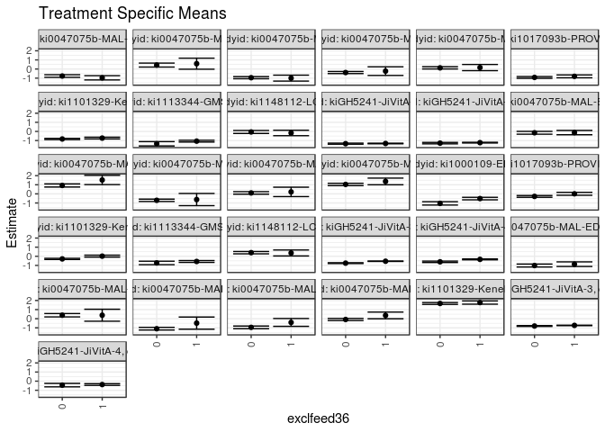

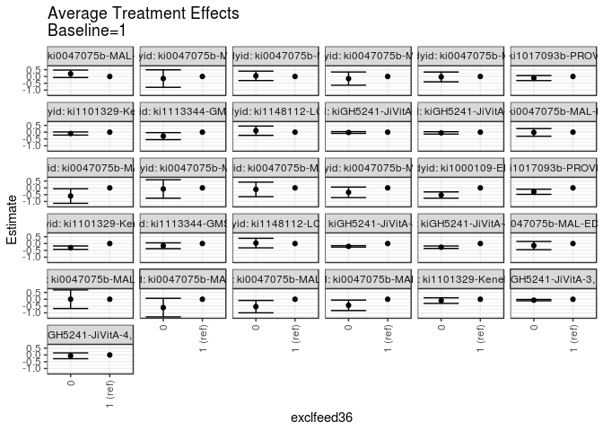

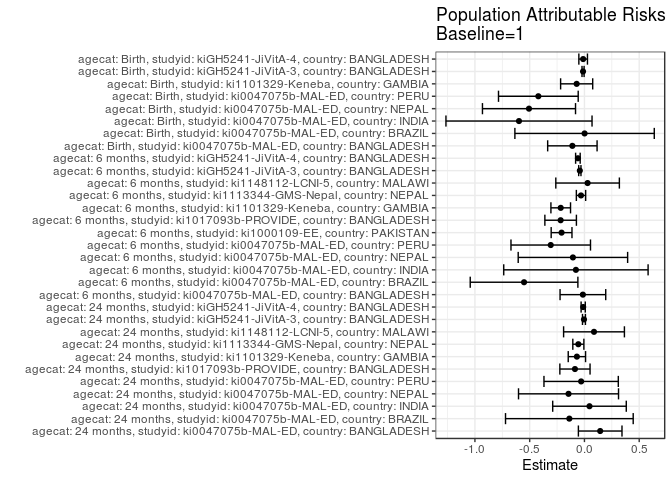

## Results Table

### Parameter: TSM

| agecat | studyid | country | intervention_level | baseline_level | estimate | ci_lower | ci_upper |
| --- | --- | --- | --- | --- | --- | --- | --- |
| Birth | ki0047075b-MAL-ED | BANGLADESH | 1 | NA | -0.8670690 | -1.1205193 | -0.6136186 |
| Birth | ki0047075b-MAL-ED | BANGLADESH | 0 | NA | -1.0144767 | -1.1776562 | -0.8512973 |
| Birth | ki0047075b-MAL-ED | BRAZIL | 1 | NA | 0.3825000 | -0.2747603 | 1.0397603 |
| Birth | ki0047075b-MAL-ED | BRAZIL | 0 | NA | 0.3838182 | 0.1992091 | 0.5684272 |
| Birth | ki0047075b-MAL-ED | INDIA | 1 | NA | -0.4840000 | -1.1529255 | 0.1849255 |
| Birth | ki0047075b-MAL-ED | INDIA | 0 | NA | -1.0973684 | -1.2418489 | -0.9528879 |
| Birth | ki0047075b-MAL-ED | NEPAL | 1 | NA | -0.4063636 | -0.8371453 | 0.0244180 |
| Birth | ki0047075b-MAL-ED | NEPAL | 0 | NA | -0.9483974 | -1.0928404 | -0.8039545 |
| Birth | ki0047075b-MAL-ED | PERU | 1 | NA | 0.3606667 | -0.0066324 | 0.7279657 |
| Birth | ki0047075b-MAL-ED | PERU | 0 | NA | -0.0853785 | -0.2020874 | 0.0313304 |
| Birth | ki1101329-Keneba | GAMBIA | 1 | NA | 1.7726377 | 1.5941186 | 1.9511567 |
| Birth | ki1101329-Keneba | GAMBIA | 0 | NA | 1.6728821 | 1.5712512 | 1.7745131 |
| Birth | kiGH5241-JiVitA-3 | BANGLADESH | 1 | NA | -0.7318376 | -0.7564770 | -0.7071982 |
| Birth | kiGH5241-JiVitA-3 | BANGLADESH | 0 | NA | -0.7990065 | -0.8464479 | -0.7515652 |
| Birth | kiGH5241-JiVitA-4 | BANGLADESH | 1 | NA | -0.3743788 | -0.4698864 | -0.2788713 |
| Birth | kiGH5241-JiVitA-4 | BANGLADESH | 0 | NA | -0.4383784 | -0.6281184 | -0.2486384 |
| 6 months | ki0047075b-MAL-ED | BANGLADESH | 1 | NA | -0.1258201 | -0.3627616 | 0.1111214 |
| 6 months | ki0047075b-MAL-ED | BANGLADESH | 0 | NA | -0.1450800 | -0.2992585 | 0.0090985 |
| 6 months | ki0047075b-MAL-ED | BRAZIL | 1 | NA | 1.5231373 | 1.0169734 | 2.0293011 |
| 6 months | ki0047075b-MAL-ED | BRAZIL | 0 | NA | 0.9228993 | 0.7514187 | 1.0943799 |
| 6 months | ki0047075b-MAL-ED | INDIA | 1 | NA | -0.6254762 | -1.2926685 | 0.0417161 |
| 6 months | ki0047075b-MAL-ED | INDIA | 0 | NA | -0.7057787 | -0.8330997 | -0.5784578 |
| 6 months | ki0047075b-MAL-ED | NEPAL | 1 | NA | 0.2163333 | -0.2995976 | 0.7322642 |
| 6 months | ki0047075b-MAL-ED | NEPAL | 0 | NA | 0.1038989 | -0.0318360 | 0.2396339 |
| 6 months | ki0047075b-MAL-ED | PERU | 1 | NA | 1.3640625 | 1.0000774 | 1.7280476 |
| 6 months | ki0047075b-MAL-ED | PERU | 0 | NA | 1.0369216 | 0.9092869 | 1.1645562 |
| 6 months | ki1000109-EE | PAKISTAN | 1 | NA | -0.5167411 | -0.6551838 | -0.3782984 |
| 6 months | ki1000109-EE | PAKISTAN | 0 | NA | -1.0438776 | -1.2278593 | -0.8598958 |
| 6 months | ki1017093b-PROVIDE | BANGLADESH | 1 | NA | 0.0090357 | -0.1529281 | 0.1709996 |
| 6 months | ki1017093b-PROVIDE | BANGLADESH | 0 | NA | -0.2772323 | -0.3749848 | -0.1794798 |
| 6 months | ki1101329-Keneba | GAMBIA | 1 | NA | 0.0156331 | -0.0913666 | 0.1226329 |
| 6 months | ki1101329-Keneba | GAMBIA | 0 | NA | -0.2865614 | -0.3504837 | -0.2226390 |
| 6 months | ki1113344-GMS-Nepal | NEPAL | 1 | NA | -0.5693144 | -0.6696471 | -0.4689817 |
| 6 months | ki1113344-GMS-Nepal | NEPAL | 0 | NA | -0.7296764 | -0.9199779 | -0.5393749 |
| 6 months | ki1148112-LCNI-5 | MALAWI | 1 | NA | 0.3640426 | 0.0368426 | 0.6912425 |
| 6 months | ki1148112-LCNI-5 | MALAWI | 0 | NA | 0.3987556 | 0.2722028 | 0.5253083 |
| 6 months | kiGH5241-JiVitA-3 | BANGLADESH | 1 | NA | -0.5413249 | -0.5649985 | -0.5176512 |
| 6 months | kiGH5241-JiVitA-3 | BANGLADESH | 0 | NA | -0.7497925 | -0.7974191 | -0.7021659 |
| 6 months | kiGH5241-JiVitA-4 | BANGLADESH | 1 | NA | -0.3375308 | -0.3848186 | -0.2902430 |
| 6 months | kiGH5241-JiVitA-4 | BANGLADESH | 0 | NA | -0.6057366 | -0.6841256 | -0.5273475 |
| 24 months | ki0047075b-MAL-ED | BANGLADESH | 1 | NA | -0.9665517 | -1.2002072 | -0.7328962 |
| 24 months | ki0047075b-MAL-ED | BANGLADESH | 0 | NA | -0.7683007 | -0.9113977 | -0.6252036 |
| 24 months | ki0047075b-MAL-ED | BRAZIL | 1 | NA | 0.5843750 | -0.0216842 | 1.1904342 |
| 24 months | ki0047075b-MAL-ED | BRAZIL | 0 | NA | 0.4322222 | 0.2149474 | 0.6494970 |
| 24 months | ki0047075b-MAL-ED | INDIA | 1 | NA | -0.9983333 | -1.3225137 | -0.6741530 |
| 24 months | ki0047075b-MAL-ED | INDIA | 0 | NA | -0.9510407 | -1.0692101 | -0.8328714 |
| 24 months | ki0047075b-MAL-ED | NEPAL | 1 | NA | -0.2310714 | -0.7032834 | 0.2411405 |
| 24 months | ki0047075b-MAL-ED | NEPAL | 0 | NA | -0.3859579 | -0.5026514 | -0.2692645 |
| 24 months | ki0047075b-MAL-ED | PERU | 1 | NA | 0.1604167 | -0.1784908 | 0.4993242 |
| 24 months | ki0047075b-MAL-ED | PERU | 0 | NA | 0.1282713 | 0.0037422 | 0.2528004 |
| 24 months | ki1017093b-PROVIDE | BANGLADESH | 1 | NA | -0.8029054 | -0.9606206 | -0.6451902 |
| 24 months | ki1017093b-PROVIDE | BANGLADESH | 0 | NA | -0.9196028 | -1.0171264 | -0.8220792 |
| 24 months | ki1101329-Keneba | GAMBIA | 1 | NA | -0.7284870 | -0.8231145 | -0.6338596 |
| 24 months | ki1101329-Keneba | GAMBIA | 0 | NA | -0.8274852 | -0.8904467 | -0.7645238 |
| 24 months | ki1113344-GMS-Nepal | NEPAL | 1 | NA | -1.0629846 | -1.1606146 | -0.9653546 |
| 24 months | ki1113344-GMS-Nepal | NEPAL | 0 | NA | -1.3543295 | -1.5934880 | -1.1151710 |
| 24 months | ki1148112-LCNI-5 | MALAWI | 1 | NA | -0.1644118 | -0.4639022 | 0.1350787 |
| 24 months | ki1148112-LCNI-5 | MALAWI | 0 | NA | -0.0573333 | -0.2193784 | 0.1047117 |
| 24 months | kiGH5241-JiVitA-3 | BANGLADESH | 1 | NA | -1.3202317 | -1.3511890 | -1.2892743 |
| 24 months | kiGH5241-JiVitA-3 | BANGLADESH | 0 | NA | -1.3411593 | -1.3973756 | -1.2849430 |
| 24 months | kiGH5241-JiVitA-4 | BANGLADESH | 1 | NA | -1.2304509 | -1.2687395 | -1.1921624 |
| 24 months | kiGH5241-JiVitA-4 | BANGLADESH | 0 | NA | -1.2822902 | -1.3609951 | -1.2035854 |

### Parameter: E(Y)

| agecat | studyid | country | intervention_level | baseline_level | estimate | ci_lower | ci_upper |
| --- | --- | --- | --- | --- | --- | --- | --- |
| Birth | ki0047075b-MAL-ED | BANGLADESH | NA | NA | -0.9773043 | -1.1153078 | -0.8393008 |
| Birth | ki0047075b-MAL-ED | BRAZIL | NA | NA | 0.3837288 | 0.2059602 | 0.5614974 |
| Birth | ki0047075b-MAL-ED | INDIA | NA | NA | -1.0816410 | -1.2241126 | -0.9391694 |
| Birth | ki0047075b-MAL-ED | NEPAL | NA | NA | -0.9126946 | -1.0520834 | -0.7733058 |
| Birth | ki0047075b-MAL-ED | PERU | NA | NA | -0.0602256 | -0.1729666 | 0.0525155 |
| Birth | ki1101329-Keneba | GAMBIA | NA | NA | 1.7015141 | 1.6127308 | 1.7902975 |
| Birth | kiGH5241-JiVitA-3 | BANGLADESH | NA | NA | -0.7445605 | -0.7677110 | -0.7214100 |
| Birth | kiGH5241-JiVitA-4 | BANGLADESH | NA | NA | -0.3861794 | -0.4712311 | -0.3011277 |
| 6 months | ki0047075b-MAL-ED | BANGLADESH | NA | NA | -0.1400243 | -0.2696346 | -0.0104140 |
| 6 months | ki0047075b-MAL-ED | BRAZIL | NA | NA | 0.9717225 | 0.8073791 | 1.1360658 |
| 6 months | ki0047075b-MAL-ED | INDIA | NA | NA | -0.7033969 | -0.8285284 | -0.5782654 |
| 6 months | ki0047075b-MAL-ED | NEPAL | NA | NA | 0.1110452 | -0.0202712 | 0.2423616 |
| 6 months | ki0047075b-MAL-ED | PERU | NA | NA | 1.0562362 | 0.9338834 | 1.1785889 |
| 6 months | ki1000109-EE | PAKISTAN | NA | NA | -0.7256065 | -0.8395859 | -0.6116270 |
| 6 months | ki1017093b-PROVIDE | BANGLADESH | NA | NA | -0.2083706 | -0.2927992 | -0.1239419 |
| 6 months | ki1101329-Keneba | GAMBIA | NA | NA | -0.2009677 | -0.2562623 | -0.1456731 |
| 6 months | ki1113344-GMS-Nepal | NEPAL | NA | NA | -0.6007161 | -0.6897580 | -0.5116742 |
| 6 months | ki1148112-LCNI-5 | MALAWI | NA | NA | 0.3927574 | 0.2737700 | 0.5117448 |
| 6 months | kiGH5241-JiVitA-3 | BANGLADESH | NA | NA | -0.5834618 | -0.6054534 | -0.5614701 |
| 6 months | kiGH5241-JiVitA-4 | BANGLADESH | NA | NA | -0.3973178 | -0.4385298 | -0.3561058 |
| 24 months | ki0047075b-MAL-ED | BANGLADESH | NA | NA | -0.8227962 | -0.9454140 | -0.7001785 |
| 24 months | ki0047075b-MAL-ED | BRAZIL | NA | NA | 0.4466272 | 0.2416144 | 0.6516401 |
| 24 months | ki0047075b-MAL-ED | INDIA | NA | NA | -0.9522907 | -1.0676596 | -0.8369219 |
| 24 months | ki0047075b-MAL-ED | NEPAL | NA | NA | -0.3764474 | -0.4898516 | -0.2630431 |
| 24 months | ki0047075b-MAL-ED | PERU | NA | NA | 0.1302000 | 0.0113848 | 0.2490152 |
| 24 months | ki1017093b-PROVIDE | BANGLADESH | NA | NA | -0.8896181 | -0.9727493 | -0.8064868 |
| 24 months | ki1101329-Keneba | GAMBIA | NA | NA | -0.7973955 | -0.8498696 | -0.7449213 |
| 24 months | ki1113344-GMS-Nepal | NEPAL | NA | NA | -1.1186923 | -1.2105469 | -1.0268377 |
| 24 months | ki1148112-LCNI-5 | MALAWI | NA | NA | -0.0771196 | -0.2204715 | 0.0662323 |
| 24 months | kiGH5241-JiVitA-3 | BANGLADESH | NA | NA | -1.3246418 | -1.3519597 | -1.2973238 |
| 24 months | kiGH5241-JiVitA-4 | BANGLADESH | NA | NA | -1.2418558 | -1.2769820 | -1.2067296 |

### Parameter: ATE

| agecat | studyid | country | intervention_level | baseline_level | estimate | ci_lower | ci_upper |
| --- | --- | --- | --- | --- | --- | --- | --- |
| Birth | ki0047075b-MAL-ED | BANGLADESH | 1 | 1 | 0.0000000 | 0.0000000 | 0.0000000 |
| Birth | ki0047075b-MAL-ED | BANGLADESH | 0 | 1 | -0.1474078 | -0.4488453 | 0.1540298 |
| Birth | ki0047075b-MAL-ED | BRAZIL | 1 | 1 | 0.0000000 | 0.0000000 | 0.0000000 |
| Birth | ki0047075b-MAL-ED | BRAZIL | 0 | 1 | 0.0013182 | -0.6813762 | 0.6840125 |
| Birth | ki0047075b-MAL-ED | INDIA | 1 | 1 | 0.0000000 | 0.0000000 | 0.0000000 |
| Birth | ki0047075b-MAL-ED | INDIA | 0 | 1 | -0.6133684 | -1.2977192 | 0.0709824 |
| Birth | ki0047075b-MAL-ED | NEPAL | 1 | 1 | 0.0000000 | 0.0000000 | 0.0000000 |
| Birth | ki0047075b-MAL-ED | NEPAL | 0 | 1 | -0.5420338 | -0.9963867 | -0.0876809 |
| Birth | ki0047075b-MAL-ED | PERU | 1 | 1 | 0.0000000 | 0.0000000 | 0.0000000 |
| Birth | ki0047075b-MAL-ED | PERU | 0 | 1 | -0.4460452 | -0.8314405 | -0.0606498 |
| Birth | ki1101329-Keneba | GAMBIA | 1 | 1 | 0.0000000 | 0.0000000 | 0.0000000 |
| Birth | ki1101329-Keneba | GAMBIA | 0 | 1 | -0.0997555 | -0.3051768 | 0.1056657 |
| Birth | kiGH5241-JiVitA-3 | BANGLADESH | 1 | 1 | 0.0000000 | 0.0000000 | 0.0000000 |
| Birth | kiGH5241-JiVitA-3 | BANGLADESH | 0 | 1 | -0.0671689 | -0.1171081 | -0.0172298 |
| Birth | kiGH5241-JiVitA-4 | BANGLADESH | 1 | 1 | 0.0000000 | 0.0000000 | 0.0000000 |
| Birth | kiGH5241-JiVitA-4 | BANGLADESH | 0 | 1 | -0.0639996 | -0.2770448 | 0.1490457 |
| 6 months | ki0047075b-MAL-ED | BANGLADESH | 1 | 1 | 0.0000000 | 0.0000000 | 0.0000000 |
| 6 months | ki0047075b-MAL-ED | BANGLADESH | 0 | 1 | -0.0192599 | -0.3019475 | 0.2634277 |
| 6 months | ki0047075b-MAL-ED | BRAZIL | 1 | 1 | 0.0000000 | 0.0000000 | 0.0000000 |
| 6 months | ki0047075b-MAL-ED | BRAZIL | 0 | 1 | -0.6002379 | -1.1346605 | -0.0658154 |
| 6 months | ki0047075b-MAL-ED | INDIA | 1 | 1 | 0.0000000 | 0.0000000 | 0.0000000 |
| 6 months | ki0047075b-MAL-ED | INDIA | 0 | 1 | -0.0803026 | -0.7595346 | 0.5989295 |
| 6 months | ki0047075b-MAL-ED | NEPAL | 1 | 1 | 0.0000000 | 0.0000000 | 0.0000000 |
| 6 months | ki0047075b-MAL-ED | NEPAL | 0 | 1 | -0.1124344 | -0.6459217 | 0.4210529 |
| 6 months | ki0047075b-MAL-ED | PERU | 1 | 1 | 0.0000000 | 0.0000000 | 0.0000000 |
| 6 months | ki0047075b-MAL-ED | PERU | 0 | 1 | -0.3271409 | -0.7128556 | 0.0585737 |
| 6 months | ki1000109-EE | PAKISTAN | 1 | 1 | 0.0000000 | 0.0000000 | 0.0000000 |
| 6 months | ki1000109-EE | PAKISTAN | 0 | 1 | -0.5271365 | -0.7573878 | -0.2968852 |
| 6 months | ki1017093b-PROVIDE | BANGLADESH | 1 | 1 | 0.0000000 | 0.0000000 | 0.0000000 |
| 6 months | ki1017093b-PROVIDE | BANGLADESH | 0 | 1 | -0.2862680 | -0.4754447 | -0.0970912 |
| 6 months | ki1101329-Keneba | GAMBIA | 1 | 1 | 0.0000000 | 0.0000000 | 0.0000000 |
| 6 months | ki1101329-Keneba | GAMBIA | 0 | 1 | -0.3021945 | -0.4268340 | -0.1775549 |
| 6 months | ki1113344-GMS-Nepal | NEPAL | 1 | 1 | 0.0000000 | 0.0000000 | 0.0000000 |
| 6 months | ki1113344-GMS-Nepal | NEPAL | 0 | 1 | -0.1603620 | -0.3754929 | 0.0547690 |
| 6 months | ki1148112-LCNI-5 | MALAWI | 1 | 1 | 0.0000000 | 0.0000000 | 0.0000000 |
| 6 months | ki1148112-LCNI-5 | MALAWI | 0 | 1 | 0.0347130 | -0.3161080 | 0.3855340 |
| 6 months | kiGH5241-JiVitA-3 | BANGLADESH | 1 | 1 | 0.0000000 | 0.0000000 | 0.0000000 |
| 6 months | kiGH5241-JiVitA-3 | BANGLADESH | 0 | 1 | -0.2084677 | -0.2595996 | -0.1573358 |
| 6 months | kiGH5241-JiVitA-4 | BANGLADESH | 1 | 1 | 0.0000000 | 0.0000000 | 0.0000000 |
| 6 months | kiGH5241-JiVitA-4 | BANGLADESH | 0 | 1 | -0.2682057 | -0.3583266 | -0.1780848 |
| 24 months | ki0047075b-MAL-ED | BANGLADESH | 1 | 1 | 0.0000000 | 0.0000000 | 0.0000000 |
| 24 months | ki0047075b-MAL-ED | BANGLADESH | 0 | 1 | 0.1982511 | -0.0757410 | 0.4722432 |
| 24 months | ki0047075b-MAL-ED | BRAZIL | 1 | 1 | 0.0000000 | 0.0000000 | 0.0000000 |
| 24 months | ki0047075b-MAL-ED | BRAZIL | 0 | 1 | -0.1521528 | -0.7959820 | 0.4916765 |
| 24 months | ki0047075b-MAL-ED | INDIA | 1 | 1 | 0.0000000 | 0.0000000 | 0.0000000 |
| 24 months | ki0047075b-MAL-ED | INDIA | 0 | 1 | 0.0472926 | -0.2977536 | 0.3923389 |
| 24 months | ki0047075b-MAL-ED | NEPAL | 1 | 1 | 0.0000000 | 0.0000000 | 0.0000000 |
| 24 months | ki0047075b-MAL-ED | NEPAL | 0 | 1 | -0.1548865 | -0.6413035 | 0.3315305 |
| 24 months | ki0047075b-MAL-ED | PERU | 1 | 1 | 0.0000000 | 0.0000000 | 0.0000000 |
| 24 months | ki0047075b-MAL-ED | PERU | 0 | 1 | -0.0321454 | -0.3932074 | 0.3289167 |
| 24 months | ki1017093b-PROVIDE | BANGLADESH | 1 | 1 | 0.0000000 | 0.0000000 | 0.0000000 |
| 24 months | ki1017093b-PROVIDE | BANGLADESH | 0 | 1 | -0.1166974 | -0.3021292 | 0.0687344 |
| 24 months | ki1101329-Keneba | GAMBIA | 1 | 1 | 0.0000000 | 0.0000000 | 0.0000000 |
| 24 months | ki1101329-Keneba | GAMBIA | 0 | 1 | -0.0989982 | -0.2126578 | 0.0146614 |
| 24 months | ki1113344-GMS-Nepal | NEPAL | 1 | 1 | 0.0000000 | 0.0000000 | 0.0000000 |
| 24 months | ki1113344-GMS-Nepal | NEPAL | 0 | 1 | -0.2913449 | -0.5496633 | -0.0330265 |
| 24 months | ki1148112-LCNI-5 | MALAWI | 1 | 1 | 0.0000000 | 0.0000000 | 0.0000000 |
| 24 months | ki1148112-LCNI-5 | MALAWI | 0 | 1 | 0.1070784 | -0.2334405 | 0.4475973 |
| 24 months | kiGH5241-JiVitA-3 | BANGLADESH | 1 | 1 | 0.0000000 | 0.0000000 | 0.0000000 |
| 24 months | kiGH5241-JiVitA-3 | BANGLADESH | 0 | 1 | -0.0209276 | -0.0846876 | 0.0428323 |
| 24 months | kiGH5241-JiVitA-4 | BANGLADESH | 1 | 1 | 0.0000000 | 0.0000000 | 0.0000000 |
| 24 months | kiGH5241-JiVitA-4 | BANGLADESH | 0 | 1 | -0.0518393 | -0.1379709 | 0.0342922 |

### Parameter: PAR

| agecat | studyid | country | intervention_level | baseline_level | estimate | ci_lower | ci_upper |
| --- | --- | --- | --- | --- | --- | --- | --- |
| Birth | ki0047075b-MAL-ED | BANGLADESH | 1 | NA | -0.1102354 | -0.3358107 | 0.1153399 |
| Birth | ki0047075b-MAL-ED | BRAZIL | 1 | NA | 0.0012288 | -0.6351812 | 0.6376388 |
| Birth | ki0047075b-MAL-ED | INDIA | 1 | NA | -0.5976410 | -1.2645839 | 0.0693018 |
| Birth | ki0047075b-MAL-ED | NEPAL | 1 | NA | -0.5063310 | -0.9312490 | -0.0814129 |
| Birth | ki0047075b-MAL-ED | PERU | 1 | NA | -0.4208922 | -0.7847657 | -0.0570188 |
| Birth | ki1101329-Keneba | GAMBIA | 1 | NA | -0.0711235 | -0.2176067 | 0.0753596 |
| Birth | kiGH5241-JiVitA-3 | BANGLADESH | 1 | NA | -0.0127229 | -0.0222173 | -0.0032285 |
| Birth | kiGH5241-JiVitA-4 | BANGLADESH | 1 | NA | -0.0118006 | -0.0510593 | 0.0274581 |
| 6 months | ki0047075b-MAL-ED | BANGLADESH | 1 | NA | -0.0142042 | -0.2226891 | 0.1942807 |
| 6 months | ki0047075b-MAL-ED | BRAZIL | 1 | NA | -0.5514148 | -1.0428736 | -0.0599559 |
| 6 months | ki0047075b-MAL-ED | INDIA | 1 | NA | -0.0779207 | -0.7370084 | 0.5811670 |
| 6 months | ki0047075b-MAL-ED | NEPAL | 1 | NA | -0.1052881 | -0.6048796 | 0.3943034 |
| 6 months | ki0047075b-MAL-ED | PERU | 1 | NA | -0.3078263 | -0.6708847 | 0.0552320 |
| 6 months | ki1000109-EE | PAKISTAN | 1 | NA | -0.2088654 | -0.3038043 | -0.1139265 |
| 6 months | ki1017093b-PROVIDE | BANGLADESH | 1 | NA | -0.2174063 | -0.3614207 | -0.0733919 |
| 6 months | ki1101329-Keneba | GAMBIA | 1 | NA | -0.2166009 | -0.3061600 | -0.1270417 |
| 6 months | ki1113344-GMS-Nepal | NEPAL | 1 | NA | -0.0314017 | -0.0738783 | 0.0110750 |
| 6 months | ki1148112-LCNI-5 | MALAWI | 1 | NA | 0.0287148 | -0.2614906 | 0.3189202 |
| 6 months | kiGH5241-JiVitA-3 | BANGLADESH | 1 | NA | -0.0421369 | -0.0525564 | -0.0317174 |
| 6 months | kiGH5241-JiVitA-4 | BANGLADESH | 1 | NA | -0.0597870 | -0.0806022 | -0.0389717 |
| 24 months | ki0047075b-MAL-ED | BANGLADESH | 1 | NA | 0.1437555 | -0.0552815 | 0.3427926 |
| 24 months | ki0047075b-MAL-ED | BRAZIL | 1 | NA | -0.1377478 | -0.7206617 | 0.4451661 |
| 24 months | ki0047075b-MAL-ED | INDIA | 1 | NA | 0.0460426 | -0.2898850 | 0.3819701 |
| 24 months | ki0047075b-MAL-ED | NEPAL | 1 | NA | -0.1453759 | -0.6019508 | 0.3111989 |
| 24 months | ki0047075b-MAL-ED | PERU | 1 | NA | -0.0302167 | -0.3696166 | 0.3091833 |
| 24 months | ki1017093b-PROVIDE | BANGLADESH | 1 | NA | -0.0867127 | -0.2245618 | 0.0511365 |
| 24 months | ki1101329-Keneba | GAMBIA | 1 | NA | -0.0689084 | -0.1480581 | 0.0102413 |
| 24 months | ki1113344-GMS-Nepal | NEPAL | 1 | NA | -0.0557077 | -0.1062123 | -0.0052031 |
| 24 months | ki1148112-LCNI-5 | MALAWI | 1 | NA | 0.0872922 | -0.1903700 | 0.3649544 |
| 24 months | kiGH5241-JiVitA-3 | BANGLADESH | 1 | NA | -0.0044101 | -0.0178532 | 0.0090330 |
| 24 months | kiGH5241-JiVitA-4 | BANGLADESH | 1 | NA | -0.0114049 | -0.0303892 | 0.0075794 |